# Storms and other severe weather events - Public Health and Economic Impact over cities

## Results

Let’s address the main question of this analysis:

*Across the United States, which types of events (as indicated in the EVTYPE variable) are most harmful with respect to population health?* In order to answer this question lets make some plots:

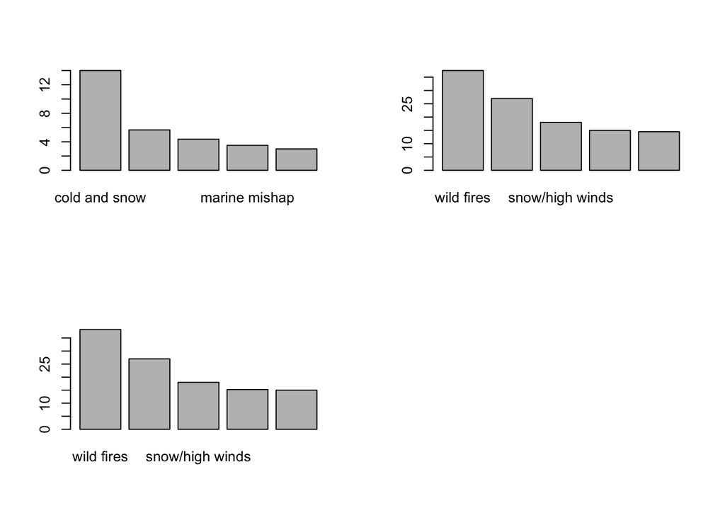

```r
# Computing mean fatalities per event
data.FATALITIES.avarage<-tapply(data$FATALITIES,data$EVTYPE,mean,na.rm=TRUE)
data.INJURIES.avarage<-tapply(data$INJURIES,data$EVTYPE,mean,na.rm=TRUE)
data.FATALITIESandINJURIES.avarage <- tapply(data$FATALITIES+data$INJURIES,data$EVTYPE,mean,na.rm=TRUE)
# Sorting the means
data.FATALITIES.avarage<-sort(data.FATALITIES.avarage, decreasing = TRUE)
data.INJURIES.avarage<-sort(data.INJURIES.avarage, decreasing = TRUE)
data.FATALITIESandINJURIES.avarage<-sort(data.FATALITIESandINJURIES.avarage, decreasing = TRUE)
# Taking the top five
data.FATALITIES.avarage<-data.FATALITIES.avarage[1:5]
data.INJURIES.avarage<-data.INJURIES.avarage[1:5]
data.FATALITIESandINJURIES.avarage <- data.FATALITIESandINJURIES.avarage[1:5]
# Generating plot
par(mfrow=c(2,2))
barplot(data.FATALITIES.avarage)
barplot(data.INJURIES.avarage)
barplot(data.FATALITIESandINJURIES.avarage)
```

From the above reulst we can say that the most harmful events from a population health point of view: - wild fires - thunderstormw - cold and snow

*Across the United States, which types of events have the greatest economic consequences?* In order to answer this question lets make some plots:

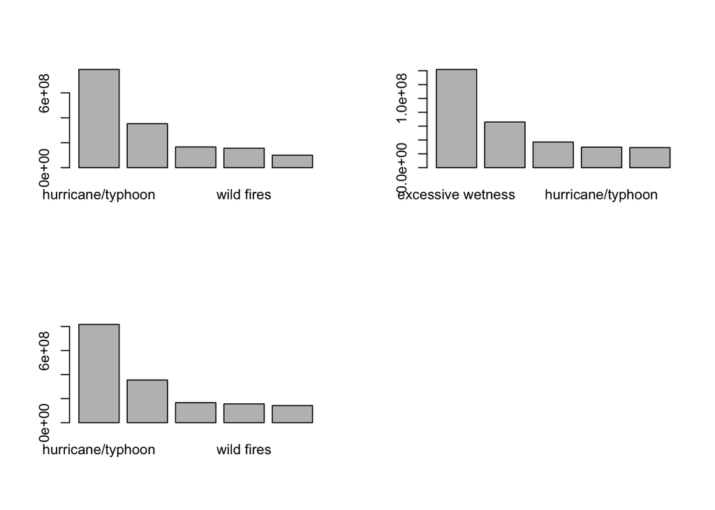

```r
# Computing mean fatalities per event
data.PROPDMG.avarage<-tapply(data$PROPDMG,data$EVTYPE,mean,na.rm=TRUE)
data.CROPDMG.avarage<-tapply(data$CROPDMG,data$EVTYPE,mean,na.rm=TRUE)
data.PROPDMGandCROPDMG.avarage <- tapply(data$PROPDMG+data$CROPDMG,data$EVTYPE,mean,na.rm=TRUE)
# Sorting the means
data.PROPDMG.avarage<-sort(data.PROPDMG.avarage, decreasing = TRUE)
data.CROPDMG.avarage<-sort(data.CROPDMG.avarage, decreasing = TRUE)
data.PROPDMGandCROPDMG.avarage<-sort(data.PROPDMGandCROPDMG.avarage, decreasing = TRUE)
# Taking the top five
data.PROPDMG.avarage<-data.PROPDMG.avarage[1:5]
data.CROPDMG.avarage<-data.CROPDMG.avarage[1:5]
data.PROPDMGandCROPDMG.avarage <- data.PROPDMGandCROPDMG.avarage[1:5]
# Generating plot
par(mfrow=c(2,2))
barplot(data.PROPDMG.avarage)
barplot(data.CROPDMG.avarage)
barplot(data.PROPDMGandCROPDMG.avarage)
```